# Assignment 4

## Setup

```r
# library(conflicted)
library(tidyverse)

theme_set(theme_classic())
```

**Assignment 4**

## Exercise 1. Bioassay model

**In this exercise, you will use a dose-response relation model that is used in Section 3.7.** **The used likelihood is the same, but instead of uniform priors, we will use a bivariate normal distribution as the joint prior distribution of the parameters $\alpha$ and $\beta$.**

Below is a description of the bioassy from the reading instructions (with some minor changes to help the grammar):

> The example is from Racine *et al.* (1986) (see ref in the end of the BDA3). [This] Swiss company makes classification[s] of chemicals to different toxicity categories defined by [governmental] authorities (like [the] EU). Toxicity classification is based on [the] lethal dose 50% (LD50) which [indicates] what amount of [a] chemical [that] kills 50% of the subjects. [The] [s]maller the LD50, [the] more lethal the chemical is. The original paper mentions “1983 Swiss poison Regulation” which defines [the] following categories for chemicals orally given to rats (mg/ml):

| Class | LD50 |
| --- | --- |
| 1 | <5 |
| 2 | 5-50 |
| 3 | 50-500 |
| 4 | 500-2000 |
| 5 | 2000-5000 |

> To reduce the number of rats needed in the experiments, the company started to use Bayesian methods. The paper mentions that in those days, [the] use of just 20 rats to define the classification was very little. [The] book gives the LD50 in log(g/ml). When the result from demo3_6 is transformed to mg/ml, we see that the mean LD50 is about 900 and $p(500 < LD50 < 2000) \approx 0.99$. Thus, the tested chemical can be classified as category 4 toxic.

**a) In the prior distribution for $\alpha, \beta)$, the marginal distributions are $\alpha \sim N(0, 2^2)$ and $\beta \sim N(10, 10^2)$, and the correlation between them is $\text{corr}(\alpha, \beta) = 0.6$.** **Report the mean (vector of two values) and covariance (two by two matrix) of the bivariate normal distribution.**

The definition of a bivariate normal distribution is

$$\begin{pmatrix} X_1 \\ X_2 \end{pmatrix}
\sim N
\begin{bmatrix}
\begin{pmatrix} \mu_1 \\ \mu_2 \end{pmatrix} ,
\begin{pmatrix}
\sigma_1^2 & \rho \sigma_2 \sigma_1 \\
\rho \sigma_1 \sigma_2 & \sigma_2^2 \\
\end{pmatrix}
\end{bmatrix}$$

Because $\alpha$ and $\beta$ are both normal distributions, but the mean vector is

$$\begin{pmatrix} \mu_\alpha \\ \mu_\beta \end{pmatrix} =
\begin{pmatrix} 0 \\ 10 \end{pmatrix}$$

and the covariance matrix is

$$\begin{aligned}
\begin{pmatrix}
\sigma_\alpha^2 & \rho \sigma_\beta \sigma_\alpha \\
\rho \sigma_\alpha \sigma_\beta & \sigma_\beta^2 \\
\end{pmatrix} &=
\begin{pmatrix}
2^2 & 0.6 \times 10 \times 2 \\
0.6 \times 2 \times 10 & 10^2 \\
\end{pmatrix} \\
&= \begin{pmatrix}
4 & 12 \\
12 & 100 \\
\end{pmatrix}
\end{aligned}$$

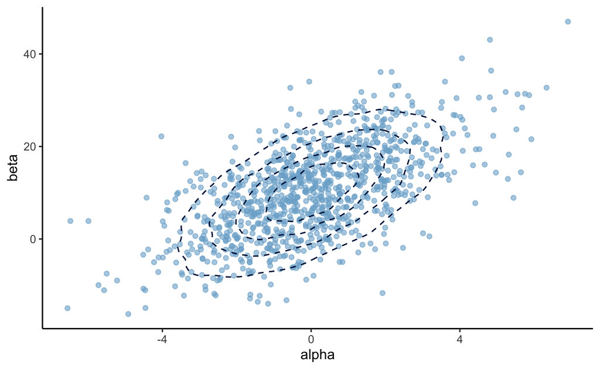

```r
N <- 1e5

mu_a <- 0
sigma_a <- 2
mu_b <- 10
sigma_b <- 10
rho <- 0.6
cov_value <- rho * sigma_a * sigma_b

mu <- c(mu_a, mu_b)
cov_mat <- matrix(
  c(sigma_a^2, cov_value, cov_value, sigma_b^2),
  nrow = 2,
  byrow = FALSE
)
bvn <- MASS::mvrnorm(N, mu = mu, Sigma = cov_mat)

plot_df <- as.data.frame(bvn) %>%
  as_tibble() %>%
  set_names("alpha", "beta")

plot_df %>%
  ggplot(aes(x=alpha, y=beta)) +
  geom_point(data=sample_n(plot_df, size=1000), alpha=0.6, color="#7AAED1") +
  geom_density_2d(bins=5, linetype=2, color="#011F4B")
```

source: [PennState, Elberl College of Science: “4.2 - Bivariate Normal Distribution”](https://online.stat.psu.edu/stat505/lesson/4/4.2)